# Caso de Estudio 2: Bellabeat - Análisis de Datos de Bienestar Inteligente

Certificado Profesional de Análisis de Datos de Google (Google Data Analytics Capstone)

Diego Hidalgo

2026-10-29

# 1 Introducción y Pregunta de Negocio (Fase: Ask)

**Bellabeat** es un fabricante de productos tecnológicos de alta gama enfocados en la salud y bienestar de las mujeres (Leaf, Time, Spring y la Bellabeat App).

La cofundadora y directora creativa, **Urška Sršen**, busca responder las siguientes preguntas clave: 1. ¿Cuáles son algunas de las tendencias actuales en el uso de dispositivos inteligentes (smart devices)? 2. ¿Cómo podrían aplicarse estas tendencias a los clientes de Bellabeat? 3. ¿Cómo pueden estas tendencias orientar la estrategia de marketing de Bellabeat?

# 2 Preparación del Entorno y Carga de Datos (Fase: Prepare)

Utilizamos el conjunto de datos público de FitBit Fitness Tracker Data (Fitabase) que contiene registros de 33 usuarios durante 30 días (abril a mayo de 2016).

```r
# Carga de librerías del ecosistema Tidyverse
library(tidyverse)
library(lubridate)
library(scales)
library(knitr)
```

```r
# Cargar datos limpios y agregados
resumen_metricas <- read_csv("reportes_resumen/resumen_general_metricas.csv")
pasos_semana <- read_csv("reportes_resumen/pasos_por_dia_semana.csv")
pasos_hora <- read_csv("reportes_resumen/pasos_por_hora.csv")
segmentacion <- read_csv("reportes_resumen/segmentacion_usuarios.csv")
datos_detallados <- read_csv("reportes_resumen/datos_detallados_actividad_sueno.csv")

# Ordenar días de la semana
dias_orden <- c("Monday", "Tuesday", "Wednesday", "Thursday", "Friday", "Saturday", "Sunday")
dias_espanol <- c("Lunes", "Martes", "Miércoles", "Jueves", "Viernes", "Sábado", "Domingo")
pasos_semana$DayOfWeek <- factor(pasos_semana$DayOfWeek, levels = dias_orden, labels = dias_espanol)
```

# 3 Exploración y Métricas Globales (Fase: Process & Analyze)

```r
kable(resumen_metricas, caption = "Métricas Clave de la Muestra Analizada (33 Usuarios)")
```

Métricas Clave de la Muestra Analizada (33 Usuarios)

| Métrica | Valor |
| --- | --- |
| Usuarios Únicos (Actividad) | 33.0 |
| Usuarios Únicos (Sueño) | 24.0 |
| Usuarios Únicos (Peso) | 9.0 |
| Pasos Diarios Promedio | 8319.4 |
| Horas Sedentarias Diarias Promedio | 15.9 |
| Minutos Activos Diarios Promedio | 23.0 |
| Horas Dormidas Promedio | 7.0 |
| Horas en Cama Promedio | 7.6 |
| Tiempo de Desvelo Promedio en Cama (min) | 39.3 |
| Eficiencia del Sueño Promedio (%) | 91.6 |

### 3.0.1 Hallazgo Fundamental:

- **33 usuarios** registraron actividad diaria, pero **solo 24 usuarios** registraron datos de sueño.
- **9 usuarios (27.3%)** nunca usaron el dispositivo para dormir, lo que evidencia la incomodidad de los relojes convencionales en la muñeca durante la noche.

# 4 Visualizaciones de Alto Impacto con ggplot2

## 4.1 1. Segmentación de Usuarios por Nivel de Actividad

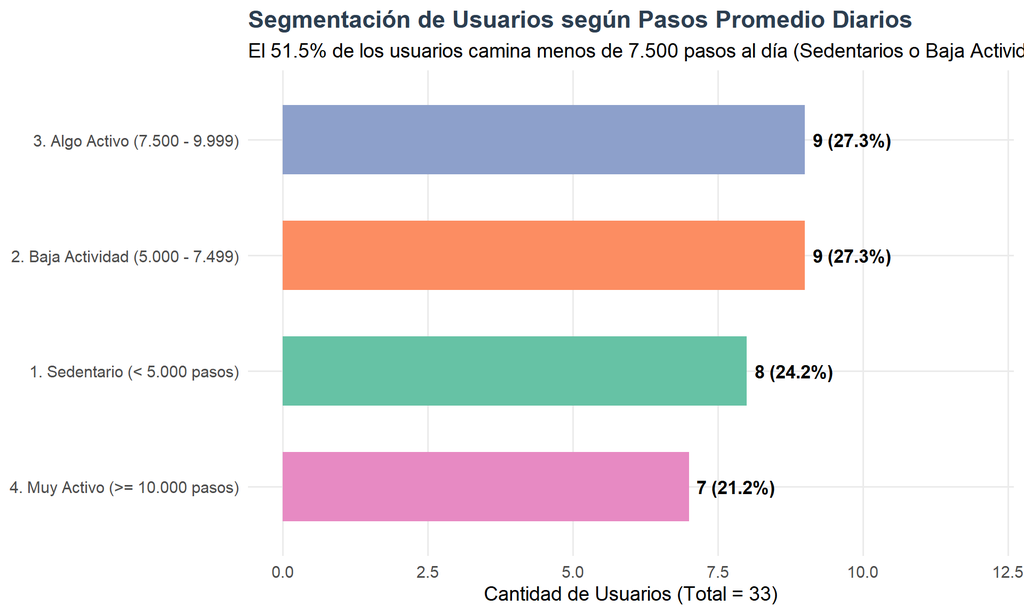

```r
ggplot(segmentacion, aes(x = reorder(tipo_usuario, cantidad_usuarios), y = cantidad_usuarios, fill = tipo_usuario)) +
  geom_col(show.legend = FALSE, width = 0.6) +
  geom_text(aes(label = paste0(cantidad_usuarios, " (", porcentaje_usuarios, "%)")),
            hjust = -0.1, size = 4.5, fontface = "bold") +
  coord_flip() +
  scale_fill_brewer(palette = "Set2") +
  scale_y_continuous(limits = c(0, 12)) +
  labs(
    title = "Segmentación de Usuarios según Pasos Promedio Diarios",
    subtitle = "El 51.5% de los usuarios camina menos de 7.500 pasos al día (Sedentarios o Baja Actividad)",
    x = NULL,
    y = "Cantidad de Usuarios (Total = 33)"
  ) +
  theme_minimal(base_size = 14) +
  theme(
    plot.title = element_text(face = "bold", color = "#2c3e50"),
    panel.grid.minor = element_blank()
  )
```

## 4.2 2. Pasos Promedio por Día de la Semana

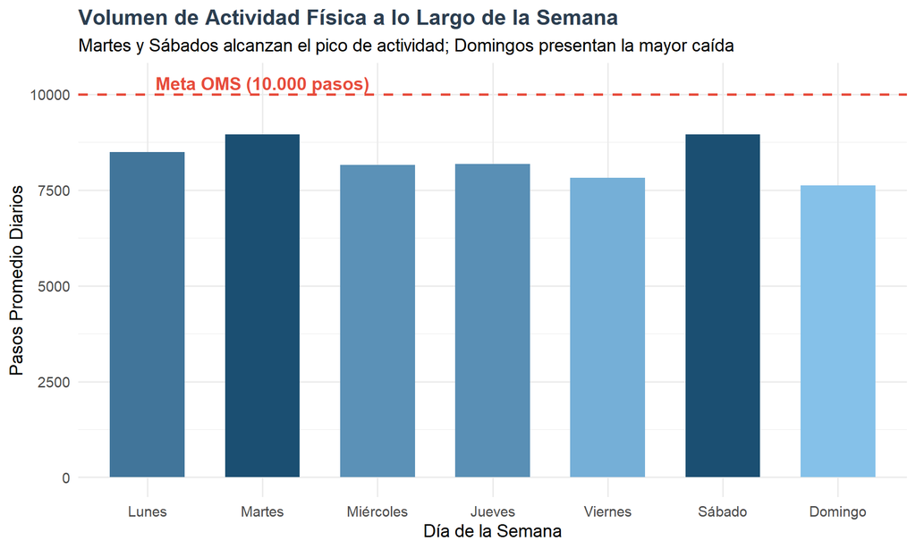

```r
ggplot(pasos_semana, aes(x = DayOfWeek, y = TotalSteps, fill = TotalSteps)) +
  geom_col(show.legend = FALSE, width = 0.65) +
  geom_hline(yintercept = 10000, linetype = "dashed", color = "#e74c3c", linewidth = 1) +
  annotate("text", x = 2, y = 10300, label = "Meta OMS (10.000 pasos)", color = "#e74c3c", fontface = "bold") +
  scale_fill_gradient(low = "#85c1e9", high = "#1b4f72") +
  labs(
    title = "Volumen de Actividad Física a lo Largo de la Semana",
    subtitle = "Martes y Sábados alcanzan el pico de actividad; Domingos presentan la mayor caída",
    x = "Día de la Semana",
    y = "Pasos Promedio Diarios"
  ) +
  theme_minimal(base_size = 14) +
  theme(plot.title = element_text(face = "bold", color = "#2c3e50"))
```

## 4.3 3. Patrón de Actividad por Hora: El “Bajón Laboral” de las 15:00 hrs

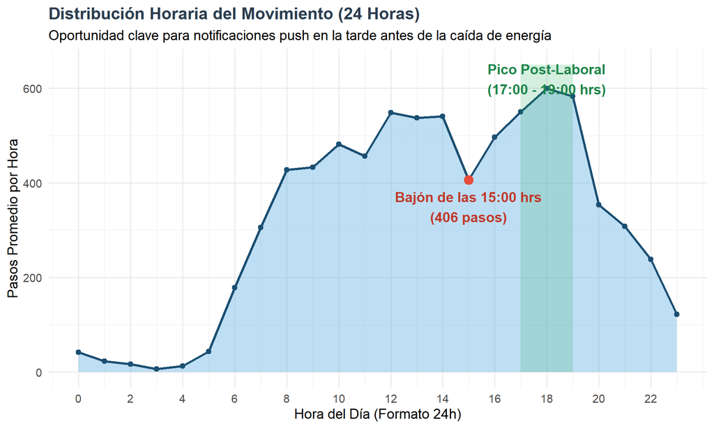

```r
ggplot(pasos_hora, aes(x = Hour, y = StepTotal)) +
  geom_area(fill = "#5dade2", alpha = 0.4) +
  geom_line(color = "#1b4f72", linewidth = 1.2) +
  geom_point(color = "#1b4f72", size = 2) +
  annotate("rect", xmin = 17, xmax = 19, ymin = 0, ymax = 650, alpha = 0.2, fill = "#27ae60") +
  annotate("text", x = 18, y = 620, label = "Pico Post-Laboral\n(17:00 - 19:00 hrs)", color = "#1e8449", fontface = "bold") +
  annotate("point", x = 15, y = 406, color = "#e74c3c", size = 4) +
  annotate("text", x = 15, y = 350, label = "Bajón de las 15:00 hrs\n(406 pasos)", color = "#c0392b", fontface = "bold") +
  scale_x_continuous(breaks = seq(0, 23, 2)) +
  labs(
    title = "Distribución Horaria del Movimiento (24 Horas)",
    subtitle = "Oportunidad clave para notificaciones push en la tarde antes de la caída de energía",
    x = "Hora del Día (Formato 24h)",
    y = "Pasos Promedio por Hora"
  ) +
  theme_minimal(base_size = 14) +
  theme(plot.title = element_text(face = "bold", color = "#2c3e50"))
```

## 4.4 4. Relación Sedentarismo vs Sueño: Dispersión con Regresión

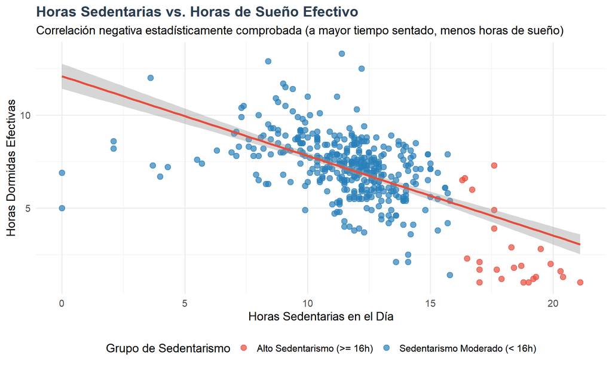

```r
ggplot(datos_detallados, aes(x = horas_sedentarias, y = horas_dormidas, color = grupo_sedentarismo)) +
  geom_point(alpha = 0.7, size = 3) +
  geom_smooth(method = "lm", color = "#e74c3c", se = TRUE, linetype = "solid", inherit.aes = FALSE,
              aes(x = horas_sedentarias, y = horas_dormidas)) +
  scale_color_manual(values = c("Alto Sedentarismo (>= 16h)" = "#e74c3c", "Sedentarismo Moderado (< 16h)" = "#2980b9")) +
  labs(
    title = "Horas Sedentarias vs. Horas de Sueño Efectivo",
    subtitle = "Correlación negativa estadísticamente comprobada (a mayor tiempo sentado, menos horas de sueño)",
    x = "Horas Sedentarias en el Día",
    y = "Horas Dormidas Efectivas",
    color = "Grupo de Sedentarismo"
  ) +
  theme_minimal(base_size = 14) +
  theme(
    plot.title = element_text(face = "bold", color = "#2c3e50"),
    legend.position = "bottom"
  )
```

# 5 Conclusiones y Recomendaciones Estratégicas (Fase: Act)

### 5.0.1 1. Ventaja Competitiva de Bellabeat Leaf frente a Relojes Inteligentes

- **El Hallazgo:** El 27.3% de los usuarios no registra sueño en Fitbit porque los smartwatches tradicionales son toscos y pesados para dormir.
- **La Acción:** Posicionar el **Bellabeat Leaf** (clip o collar ligero sin pantalla agresiva) como el rastreador de sueño más ergonómico y discreto del mercado.

### 5.0.2 2. Notificaciones Inteligentes a las 14:45 hrs

- **El Hallazgo:** Las 15:00 hrs es la hora laboral con menor movimiento del día.
- **La Acción:** Enviar micro-notificaciones desde la Bellabeat App a las 14:45 hrs invitando a una caminata de 5 minutos, pausa activa o hidratación (Spring water bottle).

### 5.0.3 3. Programa Gradual de Pasos para el 51.5% de Usuarias

- **El Hallazgo:** Más de la mitad de las usuarias camina menos de 7.500 pasos.
- **La Acción:** No imponer una meta inalcanzable de 10.000 pasos desde el día 1; crear retos escalonados (+500 pasos cada semana) acompañados de contenido de bienestar en la app.